# Covariance and Correlation

April 05, 2020

**Section 4.7**

## Covariance

*Definition.*

Let \( X \) and \( Y \) be random variables with means \( \mu_X \) and \( \mu_Y \). Then the **covariance** between \( X \) and \( Y \) is

\[ Cov[X,Y] = E[(X-\mu_X)(Y-\mu_Y)] \]

*Note.*

This is a statistic for measuring the extend of linear association between two random variables.

*Result 1.*

\[ Cov[X,Y] = E[XY] - \mu_X\mu_Y \]

This is the most commonly used form for covariance. Can you prove this form? How?

### Covariance Interpretation

\( X \) and \( Y \) are random variables; covariance asks if we see a linear association between the two draws that occur in an \( (x,y) \) pair.

Consider the function \( f(X,Y) = (X-\mu_X)(Y-\mu_Y) \).

There are four cases to consider, where we are interested in the resulting sign of \( f(X,Y) \).

\[ \small \begin{aligned} \text{I.} \quad X > \mu_X, Y > \mu_Y \quad & \quad \text{II.} \quad X < \mu_X, Y > \mu_Y \\ \text{III.} \quad X < \mu_X, Y < \mu_Y \quad & \quad \text{IV.} \quad X > \mu_X, Y < \mu_Y \\ \end{aligned} \]

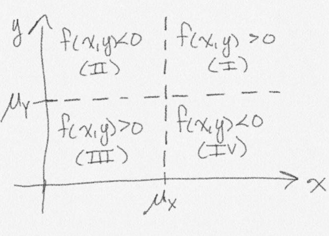

Covariance evaluates how likely observations are to be in particular quadrants.

### Covariance Interpretation

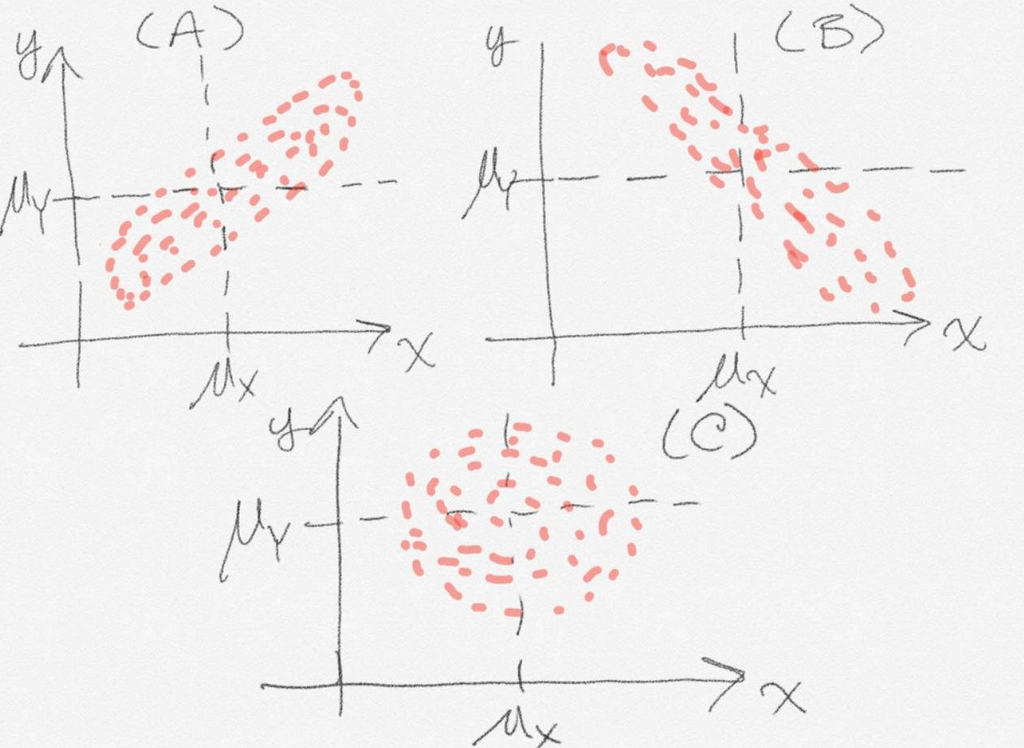

(A) If we expect to find pairs in **I** or **III**, then the random variables have a positive covariance.

- If a value of \( X \) much larger then \( \mu_X \), we expect that \( Y \) is likely much larger than \( \mu_Y \).
- If a value of \( X \) much smaller then \( \mu_X \), we expect that \( Y \) is likely much smaller than \( \mu_Y \).

(B) If we expect to find pairs in **II** or **IV**, then the random variables have a negative covariance.

- If a value of \( X \) much larger then \( \mu_X \), we expect that \( Y \) is likely much smaller than \( \mu_Y \).
- If a value of \( X \) much smaller then \( \mu_X \), we expect that \( Y \) is likely much larger than \( \mu_Y \).

(C ) If we expect to find pairs in all four quadrants, the random variables are *not* linearly associated.

## Covariance and Independence

*Result 2.*

Let \( \small X \) and \( \small Y \) be independent random variables, then \( Cov[X,Y] = 0 \).

*Proof.*

Let \( \small X \) and \( \small Y \) be independent random variables, then

\[ \begin{aligned} Cov[X,Y] &= E[XY]-\mu_X\mu_Y \\ &= E[X]E[Y] - \mu_X\mu_Y \quad &\#\text{Indepence of X and Y} \\ &= \mu_X\mu_Y - \mu_X\mu_Y = 0 \end{aligned} \]

*Note.*

The converse is not true in general; \( \small Cov[X,Y] = 0 \) does **not** imply that \( \small X \) and \( \small Y \) are independent.

### Examples

For the following set of questions, let \( \small X_1, X_2 \stackrel{iid}\sim Unif(\{1,2,3,4\}) \) and set \( \small Y = X_1 + X_2 \).

Q1. Find \( E[Y] \)

\[ \begin{aligned} E[Y] &= E[X_1 + X_2] \\ &= E[X_1] + E[X_2] \quad &\#\text{Linear Combination} \\ &= 2E[X_1] \quad &\#\text{Indentical} \\ &= 2\left(\frac{4+1}{2}\right) = 5 \quad &\#\text{Uniform Expectation} \end{aligned} \]

Q2. Find \( Var[Y] \)

\[ \begin{aligned} Var[Y] &= Var[X_1 + X_2] \\ &= Var[X_1] + Var[X_2] \quad &\#\text{Independence} \\ &= 2Var[X_1] \quad &\#\text{Indentical} \\ &= 2\left(\frac{4^2-1}{12}\right) = \frac{15}{6} = \frac{5}{2} \quad &\#\text{Uniform Variance} \end{aligned} \]

### Examples Continued

Now we consider the bivariate random variable \( \small (X_1, Y) \).

Q3. Give and draw the joint support for \( \small (X_1, Y) \).

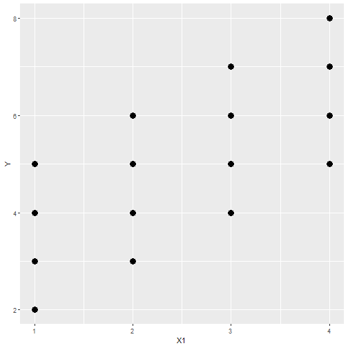

We notice that the random variables seem to have an association. As we increase \( X_1 \), it seems as though the values of \( Y \) also increase. We could have also given the joint support by listing the pairs.

\[ \begin{aligned} S_{X_1, Y} = \{&(1,2), (1,3), (1,4), (1,5), \\ &...\\ &(4,5), (4,6), (4,7), (4,8) \} \end{aligned} \]

### Examples Continued

Q4. Are \( \small X_1 \) and \( \small Y \) independent?

No. Cartesian product of the marginal supports is not equivalent to the joint support.

\[ S_{X_1} = \{1,2,3,4\} \quad \quad S_{Y} = \{2,3,...,8\} \]

Thus, \( S_{X_1,Y} \neq S_{X_1} \times S_Y \). Therefore, \( \small X_1 \) and \( \small Y \) are not independent.

Q5. What is the joint pmf for \( \small (X_1, Y) \)?

Recall that \( \small X_1, X_2 \) are uniform. Consider \( \small P(X_1 = x_1, Y = y) \).

\[ \begin{aligned} P(X_1 = x_1, Y = y) &= P(X_1 = x_1, Y = x_1 + x_2) \\ &= P(Y = x_1 + x_2|X_1 = x_1)P(X_1 = x_1) \\ &= P(X_2 = x_2)P(X_1 = x_1) \\ &= (1/4)(1/4) = 1/16 \end{aligned} \]

You could have also recognized that each observation comes from a pair of independent uniforms and arrived to this conclusion without the mathematics above. I like being able to work out the probabilities though.

We can state that the joint pmf for \( \small (X_1, Y) \) is

\[ p_{X_1, Y}(x_1,y) = \frac{1}{16}1_{S_{X_1,Y}}(x_1,y) \]

### Examples Continued

Q5. What is the covariance of \( \small (X_1, Y) \)?

\[ Cov[X_1, Y] = E[X_1Y] - \mu_{X_1}\mu_Y \]

Here we do not have that \( \small X_1 \) and \( \small Y \) are independent and must calculate for \( \small E[X_1Y] \) directly.

\[ \begin{aligned} E[X_1Y] &= \sum\limits_{(x_1,y) \in S_{X_1,Y}}(x_1y)p_{X_1, Y}(x_1,y) \\ &= \sum\limits_{(x_1,y) \in S_{X_1,Y}}\frac{x_1y}{16} \\ &= \frac{1}{16}(1(2) + 1(3) + 1(4) + 1(5) + 2(3) + ... + 4(8)) = \frac{55}{4} \end{aligned} \]

Now we can find the covariance,

\[ Cov[X_1, Y] = \frac{55}{4} - \left(\frac{5}{2}\right)(5) = \frac{5}{4} \]

### Examples Continued

How do we interpret the result that \( \small Cov[X_1, Y] = \frac{5}{4} \)?

\( \small Cov[X_1,Y] > 0 \), we can state that larger values of \( \small x_1 \) tend to be associated with larger values of \( \small Y \).

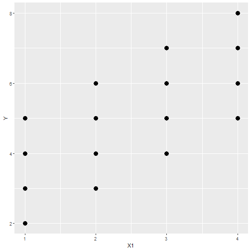

How do we discuss the strength of this relationship? This result isn't on a meaningful scale.

To discuss the covariance between any two random variables we use a standardized scale.

## Correlation

*Result 3.*

For any random variables \( \small X \) and \( \small Y \), with variances \( \small \sigma^2_X, \sigma^2_Y \), the covariance between \( \small X \) and \( \small Y \) is bounded such that

\[ -\sigma_X\sigma_Y \leq Cov[X,Y] \leq \sigma_X\sigma_Y \]

*Definition.*

The **correlation** between random variables \( \small X \) and \( \small Y \) is

\[ Corr(X,Y) = \frac{Cov[X,Y]}{\sigma_X\sigma_Y} \]

### Properties of Covariance and Correlation

(1) \( -1 \leq Corr(X,Y) \leq 1 \)

(2) Let \( Y = a + bX \).

If \( b > 0 \), then \( Cov[X,Y] > 0 \).

If \( b < 0 \), then \( Cov[X,Y] < 0 \).

When we standardize and use correlation we can state

\[ Corr(X,Y) = \begin{cases} -1 & \text{ if } \quad b < 0 \\ 1 & \text{ if } \quad b > 0 \\ 0 & \text{ if } \quad b = 0 \end{cases} \]

*Returning to Examples.*

Using the results from our earlier example, we could find that

\[ Corr(X_1, Y) = \frac{Cov[X_1,Y]}{\sigma_{X_1}\sigma_Y} = \frac{(5/4)}{\sqrt{(5/4)(5/2)}} = \frac{\sqrt{2}}{2} \approx 0.7071 \]

## Uncorrelated

*Definition.*

Random variables \( \small X \) and \( \small Y \) are **uncorrelated** if \( \small E[XY] = E[X]E[Y] \), or equivalently

\[ \text{if } Cov[X,Y] = 0 \]

or

\[ \text{if } Corr(X,Y) = 0 \]

*Results.*

If \( \small X \) and \( \small Y \) are independent then \( \small X \) and \( \small Y \) are uncorrelated.

*Important Note.*

If \( \small X \) and \( \small Y \) uncorrelated does **not**, in general, imply that \( \small X \) and \( \small Y \) are independent.